# tensorflow-MLP-stud

## MLP with TensorFlow 2

The objective of the exercise is to implement computational graphs in TensorFlow 2.0 to train and use such an architecture. The constraints we put ourselves is to use **low-level** functions of TensorFlow, i.e. we will not use high-level functions to compose layers and to train the parameters.

If you get this error in the execution of the first cell: `ModuleNotFoundError: No module named 'tensorflow'`, it probably means TensorFlow 2.0 is not installed yet on your machine.

```python
#############################
# MNIST Dataset Preparation #
#############################

import numpy as np
import tensorflow as tf
import matplotlib.pyplot as plt

mnist = tf.keras.datasets.mnist
(x_train, y_train_vec),(x_test, y_test_vec) = mnist.load_data()
x_train, x_test = x_train / 255.0, x_test / 255.0
x_train = x_train.reshape(60000, 784)
x_test = x_test.reshape(10000, 784)
# convert class vectors to binary class matrices
y_train = tf.keras.utils.to_categorical(y_train_vec, 10, dtype='float64')
y_test = tf.keras.utils.to_categorical(y_test_vec, 10, dtype='float64')
N = x_train.shape[0]         # number of samples
D = x_train.shape[1]         # dimension of input sample
n_classes = y_train.shape[1] # output dim
print('MNIST data set ready. N={}, D={}, n_classes={}'.format(N,D,n_classes))
```

```
MNIST data set ready. N=60000, D=784, n_classes=10
```

```python
# Function to sample a random batch from dataset
def next_batch(num, data, labels):
    '''
    Return a total of `num` random samples and labels.
    '''
    idx = np.arange(0,len(data))  # create an array of index values
    np.random.shuffle(idx)        # shuffle it
    idx = idx[:num]               # take the first n indexes = size of batch
    data_shuffle = data[idx]      # extract the batch using the random indexes
    labels_shuffle = labels[idx]  # extract the labels using the random indexes

    return data_shuffle, labels_shuffle
```

```python
##################
# Training phase #
##################

E = 50                # number of epochs
B = 128               # batch size
N = x_train.shape[0]  # number of samples
D = x_train.shape[1]  # dimension of input sample
H = 300               # number of neurons
A = 1              # learning rate alpha

# Linear LR decay over a few epoch until some minimum LR is reached
min_learning_rate = 0.001
normal_epochs = 15
decaying_epochs = 20

decay_per_epoch = (A - min_learning_rate) / decaying_epochs

##############################################
#  COMPLETE CODE BELOW WHERE YOU SEE # ...   #
##############################################

# Build the computational graph
@tf.function # this decorator tells tf that a graph is defined
def mlp_train(x, y, alpha):
    # define nodes for forward computation for hidden neurons h and output neurons y_pred
    h = tf.nn.relu(tf.matmul(x, w1) + b1)  # output of first layer after ReLu activation
    y_pred = tf.nn.sigmoid(tf.matmul(h, w2) + b2) # output of second layer after sigmoid activation
    # define nodes for forward computation for hidden neurons h and output neurons y_pred
    diff = y - y_pred
    loss = tf.reduce_sum(diff**2) / B
    # define the gradients
    grad_w1, grad_b1, grad_w2, grad_b2 = tf.gradients(ys=loss, xs=[w1, b1, w2, b2])
    # compute the new values of the gradients with the assign method (see slides)
    w1.assign(w1 - alpha * grad_w1)
    b1.assign(b1 - alpha * grad_b1)
    w2.assign(w2 - alpha * grad_w2)
    b2.assign(b2 - alpha * grad_b2)
    return y_pred, loss

# Init the tf.Variables w1, b1, w2, b2 following the given examples
w1 = tf.Variable(tf.random.truncated_normal((D, H), stddev = 0.1, dtype='float64'))
b1 = tf.Variable(tf.constant(0.0, shape=[H], dtype='float64'))
w2 = tf.Variable(tf.random.truncated_normal((H, 10), stddev = 0.1, dtype='float64'))
b2 = tf.Variable(tf.constant(0.0, shape=[10], dtype='float64'))


# Run the computational graph
J = [] # to store the evolution of loss J for each epoch
for epoch in range(E):
    J_epoch = 0.0
    for _ in range(int(N/B)): # number of batches to visit for 1 epoch
        # get batches calling the next_batch method provided above
        x_train_batch, y_train_batch = next_batch(B, x_train, y_train)
        with tf.device('/CPU:0'):  # change to /GPU:0 to move it to GPU
            # call the graph with the batched input, target and alpha A

            a = tf.math.maximum(A - (epoch - normal_epochs) * decay_per_epoch, min_learning_rate)
            a = tf.math.minimum(a, A)

            out = mlp_train(x_train_batch, y_train_batch, A)
        y_pred, loss_val = out
        J_epoch += loss_val
    J.append(J_epoch)
    print("epoch = {}, loss = {}, LR = {}".format(epoch, J_epoch, a))
```

```
epoch = 0, loss = 414.98351114468716, LR = 1.0
epoch = 1, loss = 263.53081651915954, LR = 1.0
epoch = 2, loss = 85.74426314893836, LR = 1.0
epoch = 3, loss = 59.82922289279294, LR = 1.0
epoch = 4, loss = 25.49602009322092, LR = 1.0
epoch = 5, loss = 20.428190501909246, LR = 1.0
epoch = 6, loss = 17.173902176857094, LR = 1.0
epoch = 7, loss = 15.318501263470454, LR = 1.0
epoch = 8, loss = 13.40826686150979, LR = 1.0
epoch = 9, loss = 12.07477002138388, LR = 1.0
epoch = 10, loss = 10.613758138505364, LR = 1.0
epoch = 11, loss = 9.877110059570436, LR = 1.0
epoch = 12, loss = 8.37586458301957, LR = 1.0
epoch = 13, loss = 8.20719573462335, LR = 1.0
epoch = 14, loss = 7.479484024799915, LR = 1.0
epoch = 15, loss = 7.0995657249303, LR = 1.0
epoch = 16, loss = 5.977784102673979, LR = 0.9500499963760376
epoch = 17, loss = 5.957027075081586, LR = 0.9000999927520752
epoch = 18, loss = 5.515956361739638, LR = 0.8501499891281128
epoch = 19, loss = 5.2220104501466675, LR = 0.8001999855041504
epoch = 20, loss = 5.148774787744019, LR = 0.750249981880188
epoch = 21, loss = 4.474466511498599, LR = 0.7002999782562256
epoch = 22, loss = 4.483960289008704, LR = 0.6503499746322632
epoch = 23, loss = 4.010951513217865, LR = 0.6003999710083008
epoch = 24, loss = 3.5944941998518978, LR = 0.5504500269889832
epoch = 25, loss = 3.705571361241484, LR = 0.5005000233650208
epoch = 26, loss = 3.479863683496848, LR = 0.45054998993873596
epoch = 27, loss = 3.3537588201398587, LR = 0.40059998631477356
epoch = 28, loss = 3.2600590381538517, LR = 0.35065001249313354
epoch = 29, loss = 3.2185161997873175, LR = 0.30070000886917114
epoch = 30, loss = 3.294546561081955, LR = 0.25075000524520874
epoch = 31, loss = 2.6650370164629615, LR = 0.20080000162124634
epoch = 32, loss = 2.7610250439550326, LR = 0.15084999799728394
epoch = 33, loss = 2.843707800369054, LR = 0.10090000182390213
epoch = 34, loss = 2.4999878822665207, LR = 0.05094999819993973
epoch = 35, loss = 2.2848581813941737, LR = 0.0010000000474974513
epoch = 36, loss = 2.2194942598433087, LR = 0.0010000000474974513
epoch = 37, loss = 2.387938891835991, LR = 0.0010000000474974513
epoch = 38, loss = 2.3096560295392754, LR = 0.0010000000474974513
epoch = 39, loss = 2.315664592877311, LR = 0.0010000000474974513
epoch = 40, loss = 2.1737459302354587, LR = 0.0010000000474974513
epoch = 41, loss = 2.1113455544561455, LR = 0.0010000000474974513
epoch = 42, loss = 2.1564810106054693, LR = 0.0010000000474974513
epoch = 43, loss = 1.8590369802705982, LR = 0.0010000000474974513
epoch = 44, loss = 2.0163803656633035, LR = 0.0010000000474974513
epoch = 45, loss = 2.248047174996608, LR = 0.0010000000474974513
epoch = 46, loss = 1.945483821545678, LR = 0.0010000000474974513
epoch = 47, loss = 1.9728908179903382, LR = 0.0010000000474974513
epoch = 48, loss = 1.6801407667281938, LR = 0.0010000000474974513
epoch = 49, loss = 1.757689406095666, LR = 0.0010000000474974513
```

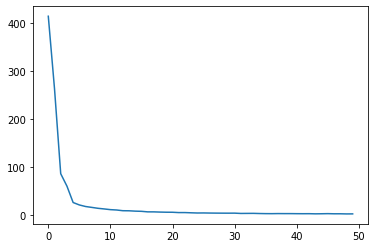

```python
# Plot the evolution of the loss
plt.plot(J)
```

```python
#################
# Testing phase #
#################

N = x_test.shape[0]  # number of samples
D = x_test.shape[1]  # dimension of input sample

##############################################
#  COMPLETE CODE BELOW WHERE YOU SEE # ...   #
##############################################
# Build the computational graph
@tf.function # this decorator tells tf that a graph is defined
def mlp_test(x, y):
    h = tf.nn.relu(tf.matmul(x, w1) + b1)  # output of first layer after ReLu activation
    y_pred = tf.nn.sigmoid(tf.matmul(h, w2) + b2) # output of second layer after sigmoid activation
    return y_pred

# Run the computational graph
with tf.device('/CPU:0'):  # change to /GPU:0 to move it to GPU
    y_pred_test = mlp_test(x_test, y_test)

print('Forward pass on test set done.')
# At this stage, y_pred_test should contain the matrix of outputs on the test set with shape (N_test, 10)
```

```
Forward pass on test set done.
```

```python
# compute accuracy
y_winner = np.argmax(y_pred_test, axis=1)
N_test = y_winner.size
num_correct = (y_winner == y_test_vec).sum()
num_missed = N_test - num_correct
accuracy = num_correct * 1.0 / N_test
error_rate = num_missed * 1.0 / N_test
print('# samples  : ', N_test)
print('# correct  : ', num_correct)
print('# missed   : ', num_missed)
print('accuracy   :  %2.2f %%'% (accuracy*100.0))
print('error rate :  %2.2f %%'% (error_rate*100.0))
```

```
# samples  :  10000
# correct  :  9835
# missed   :  165
accuracy   :  98.35 %
error rate :  1.65 %
```